# R Cheat Sheet

2025-02-03

This is a document meant to serve as resource for coding with R. It combines my knowledge so far and is intended to remind me of the basics as I am learning and getting more familiar with R. I will contiue to add to this over time. Enjoy!

#### Resources

Colors for R: http://www.stat.columbia.edu/~tzheng/files/Rcolor.pdf

Graphing Info: https://r-graph-gallery.com/

R for Data Science: https://r4ds.hadley.nz/

The ggplot2 Book: https://ggplot2-book.org/

GGplot Extensions Gallery: https://exts.ggplot2.tidyverse.org/gallery/

**Option + Shift + K** => opens up keyboard shortcuts

**Cmd/Ctrl + Shift + 0/F10** => restart R **Cmd/Ctrl + Shift + S** => re-run the current script.

Setting up data to get help (Reprex) https://r4ds.hadley.nz/workflow-help.html

## 1. Introduction

### Installing Packages

```r
install.packages("tidyverse")
library(tidyverse)
```

### 1.1 Uploading Data

Uploading data requires you to understand your working directory. The package **here** is very helpful for easily navigating directory trees

```r
getwd() #tells you working directory
```

Once you know your working directory you can choose and import your data:

```r
# Under read.csv all you need is the file directory
df <- read.csv(here("data", "sleep_score.csv")) # you can also use the here package which allows you to easily navigate through the directory tree
```

If you need to skip line when uploading data use skip = n

```r
read_csv(
  "The first line of metadata
  The second line of metadata
  x,y,z
  1,2,3",
  skip = 2
)
```

R has a bunch of built in data to work with. To see what data sets are available run:

```r
data()
```

### 1.2 Variables and Functions

Using R involves assigning variables and is done with the <-

**<- can be quickly typed using: Opt. + -

```r
a <- 5
b <- 6

ages <- c(5,6)
names <- c("Gabe", "Colin")
friends <- data.frame(names, ages)
```

To look at the data/variables you create use the view command, str will give you structure:

```r
View(friends)
str(friends) #gives you structure
```

```
## 'data.frame':    2 obs. of  2 variables:
##  $ names: chr  "Gabe" "Colin"
##  $ ages : num  5 6
```

You can also look at specific parts of data such as individual variables or individual rows and columns

```r
friends$ages # variables
friends [1,1] #rows, columns
friends [1,]
friends [,1]
```

### 1.3 Saving Data

To save data you have been working on use *write_csv* where the first argument is the dataframe and the second is the new file name

```r
write_csv(students, "students-2.csv")
read_csv("students-2.csv")
```

One problem with *write_csv* is that it DOES NOT save column specification, so *write_rds* can be used instead:

```r
write_rds(students, "students.rds")
read_rds("students.rds")
```

## 2. Tidyverse

Tidyverse in an amazing package used to write code that is more efficient and concise. Tidyverse relies on the pipe opperator which basically means “and then”

**Pipe Operator = %>% (shift + CNTL + m), basically means and then**

Here is an example of how to use tidverse to filter and plot a dataset:

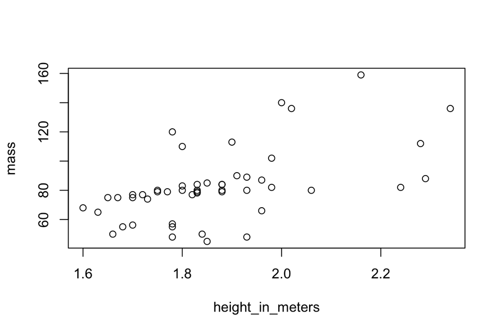

```r
starwars %>%
  filter(height > 150 & mass <200) %>% # filtering
  mutate(height_in_meters = height/100) %>% # mutate = change, making a new variable here
  select(height_in_meters, mass) %>% # what variables to work with
  arrange(mass) %>% # how to arrange (can use - to invert it)
  plot()
```

## 3. Explore

### 3.1 Asking Questions

When starting your data analysis you should be asking a lot of questions to help you conduct a thorough analysis. Two kinds of questions that are very useful are shown below

1. What type of variation occurs within my variables?
2. What type of covariation occurs between my variables?

### 3.2 Data structures and variables

There are numerous commands that are useful for looking at and viewing data. Here I will provide them and a breift description of what they do:

**view**(msleep) => view the whole df  
**glimpse**(msleep) => provides an overview of the df overview of data: names, types of variable  
**head**(msleep) => shows only the first 6 rows  
**class**(msleep$name) => shows the type of data  
**length**(msleep$name) => tells you how many observations  
**names**(msleep) => gives a list of the names of the variables in a df  
**unique**(msleep$vore) => shows the unique objects in variable

### 3.3 Missing data

Here is a line of code that is good for seeing missing data => **!** inverts data, **complete.cases** gives list of which there is no missing data

```r
missing <- !complete.cases(msleep)
msleep[missing,] #list of rows with missing data
```

## 4. Clean/Manipulate

The ultimate goal is to create tidy data. There are three interrelated rules that make a dataset tidy:

1. Each variable is a column; each column is a variable.
2. Each observation is a row; each row is an observation.
3. Each value is a cell; each cell is a single value.

Why ensure that your data is tidy? There are two main advantages:

1. There’s a general advantage to picking one consistent way of storing data. If you have a consistent data structure, it’s easier to learn the tools that work with it because they have an underlying uniformity.
2. There’s a specific advantage to placing variables in columns because it allows R’s vectorized nature to shine. Most built-in R functions work with vectors of values. That makes transforming tidy data feel particularly natural.

### 4.1 Manipulating Rows

#### 4.1.1 Filter

*filter()* = allows you to keep rows based on the values of the columns

```r
flights %>%
  filter(dep_delay > 120)
```

%in% can be used to shorten code

```r
# Flights that departed in January or February
flights %>%
  filter(month == 1 | month == 2) # | means or

flights %>%
  filter(month %in% c(1, 2))
```

#### 4.1.2 Arrange

*arrange()* = changes the order of rows

```r
flights %>%
  arrange(year, month, day, dep_time)
```

#### 4.1.3 Desc

*desc()* can be added to re-order the df from big to small

```r
flights %>%
  arrange(desc(dep_delay))
```

#### 4.1.4 Distinct

*distinct()* = finds unique rows in a dataset

```r
flights %>%
  distinct()

flights %>%
  distinct(origin, dest) # only keeps orgin and dest columns

flights %>%
  distinct(origin, dest, .keep_all = TRUE) # keeps all columns
```

#### 4.1.5 Count

*count()* = used to find number of occurances

```r
flights %>%
  count(origin, dest, sort = TRUE)
```

### 4.2 Manipulating Columns

#### 4.2.1 Mutate

*mutate()* = add new columns that are calculated from existing columns

```r
flights %>%
  mutate(
    gain = dep_delay - arr_delay,
    speed = distance / air_time * 60,
    .after = day #this line changes where the new columns are placed
  )
```

Variable type can also be changed using **mutate**

```r
starwars %>%
  mutate(hair_color = as.character(hair_color)) %>%
  glimpse()
```

You can easily change the way a variable is coded to fit a new format using **mutate**

```r
starwars %>%
  select(sex) %>%
  mutate(sex = recode(sex,
                      "male" = "man",
                      "female" = "woman")) #Change male and female
```

#### 4.2.2 Select

*select()* = allows you to select only a part of a dataset

```r
# Select using column names
starwars %>%
  select(name, height, mass)

# Select using column numbers
starwars %>%
  select(1:3)
```

Other modifiers that can be used in *select()* are shown below:

*starts_with(“abc”)* = matches names that begin with “abc”.  
*ends_with(“xyz”)* = matches names that end with “xyz”.  
*contains(“ijk”)* = matches names that contain “ijk”.  
*num_range(“x”, 1:3)* = matches x1, x2 and x3.

*select()* can also be used to rename a variable

```r
flights %>%
  select(tail_num = tailnum) #NEW variable is listed first
```

#### 4.2.3 Rename

*rename()* = should be used to keep all existing variables and just rename a few

```r
flights %>%
  rename(tail_num = tailnum)
```

#### 4.2.4 Relocate

*relocate()* = used to move variables around

```r
# Move important variables to the front
flights %>%
  relocate(time_hour, air_time)

# Specify where to put variables
flights %>%
  relocate(year:dep_time, .after = time_hour)

flights %>%
  relocate(starts_with("arr"), .before = dep_time)
```

### 4.3 Manipulating Groups

#### 4.3.1 Group_by

*group_by()* = divide data set into groups meaningful for analysis, subsequent outputs work in the group

```r
flights %>%
  group_by(month)
```

You can *group_by* multiple variables

```r
daily <- flights %>%
  group_by(year, month, day)
```

#### 4.3.2 Summarize

*summarize()* = presents summary stats, if used with group does one per group

```r
flights %>%
  group_by(month) %>%
  summarize(
    avg_delay = mean(dep_delay, na.rm = TRUE),
    n = n()
  )
```

#### 4.3.3 Slice

*slice_* = allows you to extract specific rows from groups

df %>% *slice_head(n = 1)* = takes the first row from each group.  
df %>% *slice_tail(n = 1)* = takes the last row in each group.  
df %>% *slice_min(x, n = 1)* = takes the row with the smallest value of column x.  
df %>% *slice_max(x, n = 1)* = takes the row with the largest value of column x.  
df %>% *slice_sample(n = 1)* = takes one random row.

```r
flights %>%
  group_by(dest) %>%
  slice_max(arr_delay, n = 1) %>% # n = # can be replaced with p = # to give a proportion of the data set
  relocate(dest)
```

#### 4.3.4 Ungroup

*ungroup()* = ungroups the data

```r
daily %>%
  ungroup()
```

#### 4.3.5 .by

*.by* = can be used to group within a single operation

```r
flights %>%
  summarize(
    delay = mean(dep_delay, na.rm = TRUE),
    n = n(),
    .by = month
  )

flights %>%
  summarize(
    delay = mean(dep_delay, na.rm = TRUE),
    n = n(),
    .by = c(origin, dest)
  )
```

### 4.4 Variable Order

The select command can also be used to reorder a dataset

```r
starwars %>%
  select(name, mass, height, everything())
```

### 4.5 Factor Levels

Factor levels are used to order categorical variables in useful ways. For example with looking at month data, months wil by default be ordered alphabetically. To change this you can order it using the **mutate** command. See how this is done using sex data:

```r
df <- starwars
df$sex <- as.factor(df$sex)
levels(df$sex)
```

```
## [1] "female"         "hermaphroditic" "male"           "none"
```

```r
df<- df %>%
  mutate(sex = factor(sex,
                      levels = c("male", "female","hermaphroditic", "none"
                                 )))
levels(df$sex)
```

```
## [1] "male"           "female"         "hermaphroditic" "none"
```

### 4.6 Missing Data

When working with dataset with missing data you can run into issues:

```r
mean(starwars$height) #NA bc of missing data
```

```
## [1] NA
```

To fix this you can remove NA/missing data from calculations:

```r
mean(starwars$height, na.rm = T) # NA remove = True
```

```
## [1] 174.6049
```

### 4.7 Conditional change (if_else)

Using **if_else** we can change how a variable is displayed such as createing a categorical variable from a discrete:

```r
starwars %>%
  mutate(height_m = height/100) %>%
  select(name, height, height_m) %>%
  mutate(tallness =
           if_else(height_m < 1, "short", "tall")) #condition, if met, else
```

### 4.8 Reshape data

#### 4.8.1 Intro

Sometimes the data we are using is not in the format we want it to be (short vs. long). Take the gapminder data for example:

```r
head(data)
```

```
## # A tibble: 6 × 3
##   country      year lifeExp
##   <fct>       <int>   <dbl>
## 1 Afghanistan  1952    28.8
## 2 Afghanistan  1957    30.3
## 3 Afghanistan  1962    32.0
## 4 Afghanistan  1967    34.0
## 5 Afghanistan  1972    36.1
## 6 Afghanistan  1977    38.4
```

#### 4.8.2 Pivot_wider

This data is in long format where each country is represented multiple times in multiple rows. What we can do is using the **pivot_wider** function to change the data. The code below is pulling from the “year” column to make new headers for each year, THEN it is filling those with the values for “lifeExp”

```r
wide_data <- data %>%
  pivot_wider(names_from = year, values_from = lifeExp)
head(wide_data)
```

```
## # A tibble: 6 × 13
##   country  `1952` `1957` `1962` `1967` `1972` `1977` `1982` `1987` `1992` `1997`
##   <fct>     <dbl>  <dbl>  <dbl>  <dbl>  <dbl>  <dbl>  <dbl>  <dbl>  <dbl>  <dbl>
## 1 Afghani…   28.8   30.3   32.0   34.0   36.1   38.4   39.9   40.8   41.7   41.8
## 2 Albania    55.2   59.3   64.8   66.2   67.7   68.9   70.4   72     71.6   73.0
## 3 Algeria    43.1   45.7   48.3   51.4   54.5   58.0   61.4   65.8   67.7   69.2
## 4 Angola     30.0   32.0   34     36.0   37.9   39.5   39.9   39.9   40.6   41.0
## 5 Argenti…   62.5   64.4   65.1   65.6   67.1   68.5   69.9   70.8   71.9   73.3
## 6 Austral…   69.1   70.3   70.9   71.1   71.9   73.5   74.7   76.3   77.6   78.8
## # ℹ 2 more variables: `2002` <dbl>, `2007` <dbl>
```

#### 4.8.3 Pivot_longer

This code uses the **pivot_longer** function to reverse what was done

```r
long_data <- wide_data %>%
  pivot_longer(2:13,
               names_to = "year",
               values_to = "lifeExp")
view(long_data)
```

## 5. Describe

### Summary stats

Summary statistics can be individually generated, generated all at once, or generates for multiple varibles using a few simple commands:

```r
mean(msleep$awake)
summary(msleep$awake)

msleep %>%
  select(awake, sleep_total) %>%
  summary()
```

### Summarize your data

Tidyverse also allows you to easily maniplulate and summarize your data, see the example below:

```r
msleep %>%  # select your data
  drop_na(vore) %>% #remove missing values
  group_by(vore) %>% #group by type => "vore"
  summarize(Lower = min(sleep_total), #create variable headings = function(variable you want value)
            Average = mean(sleep_total),
            Upper = max(sleep_total),
            Difference = max(sleep_total)-min(sleep_total)) %>%
  arrange(Average) %>% #put in order by "average" value
  View()
```

### Create tables

Tables can be useful ways of displaying data. Tables can be simple:

```r
table(msleep$vore) #gives us a count of occurrences of variable
```

```
##
##   carni   herbi insecti    omni
##      19      32       5      20
```

Or more complex

```r
msleep %>%
  select(vore, order) %>%
  filter(order %in% c("Rodentia", "Primates")) %>% #saying if in the order column there is ANY of the following variables, include them
  table()
```

```
##        order
## vore    Primates Rodentia
##   carni        1        1
##   herbi        1       16
##   omni        10        2
```

## 6. Visualize

### 6.1 Grammar of Graphics

In order to make graphs we need to understand what we are talking about

```
Data => what data are you using
Mapping => using aesthetics (x and y axis, color, shape, size, etc.)
Geometry => line, bar chart, histograms, etc.
```

##### Here I provide code to different graph types. The code gets increasily complex and can be used to develop your own figures, but here is an overall template for making graphs

ggplot(data = ) + ( mapping = aes(), stat = , position = ) + +

### 6.2 Bar charts

Bar charts are used to display categorical data:

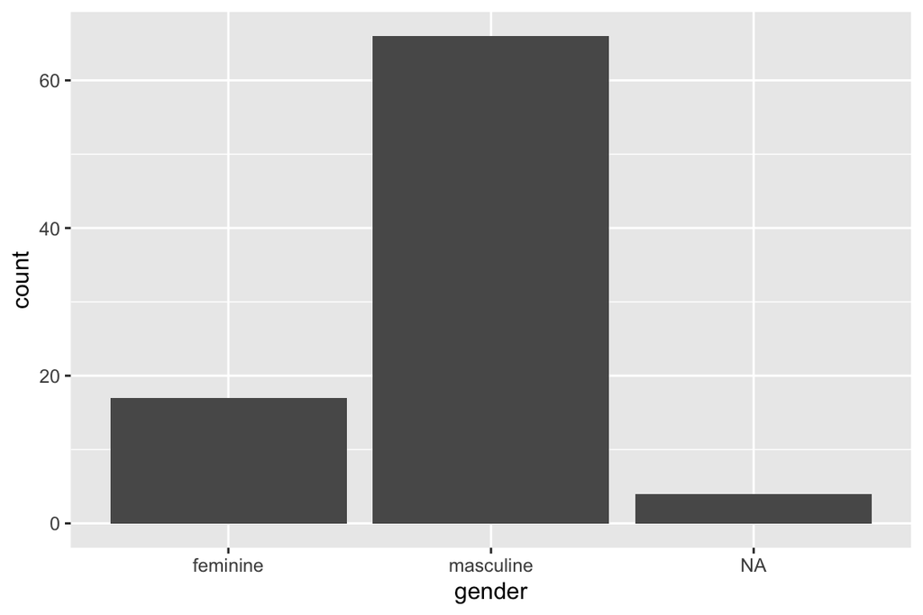

```r
ggplot(data = starwars,
       mapping = aes(x = gender)) +
  geom_bar()
```

### 6.3 Histograms

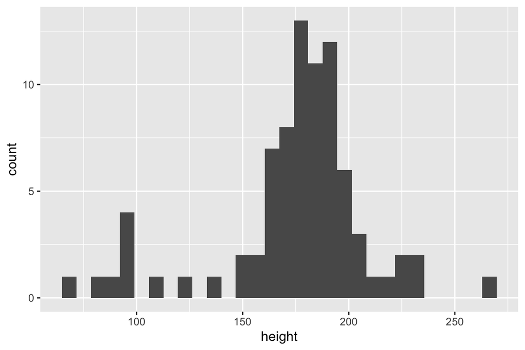

```r
starwars %>% #piping data in allows you to do stuff with it BEFORE it gets to the graphic
  drop_na(height) %>% #such as filter out missing data
  ggplot(aes(x = height)) + #autofills in starwars for first argument = data
  geom_histogram()
```

### 6.4 Density Plots

Density plots are basically smoothed out histograms

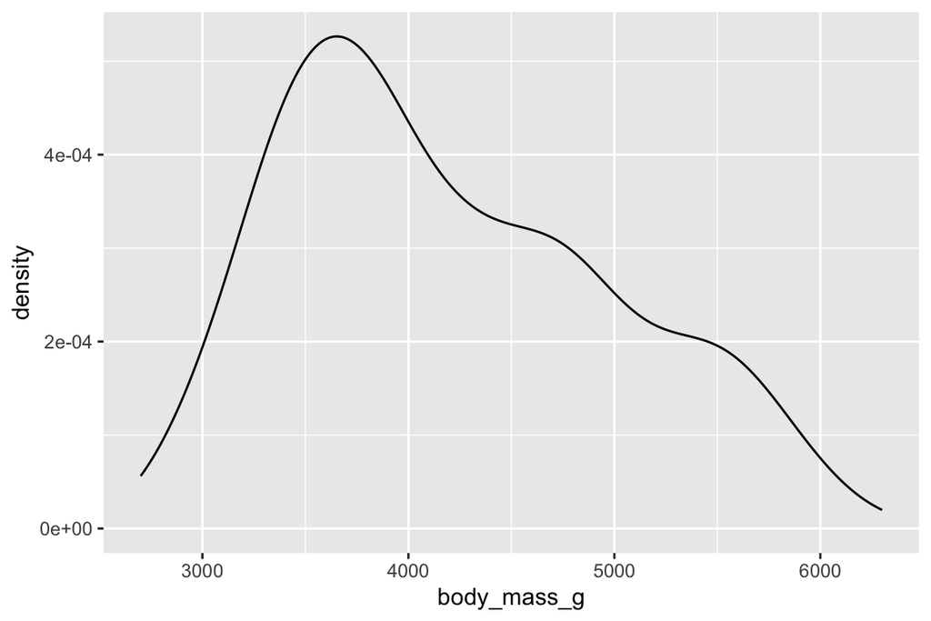

```r
ggplot(penguins, aes(x = body_mass_g)) + # density plots => smoothed histograms
  geom_density()
```

### 6.5 Box plots

Boxplots display distributions of data:

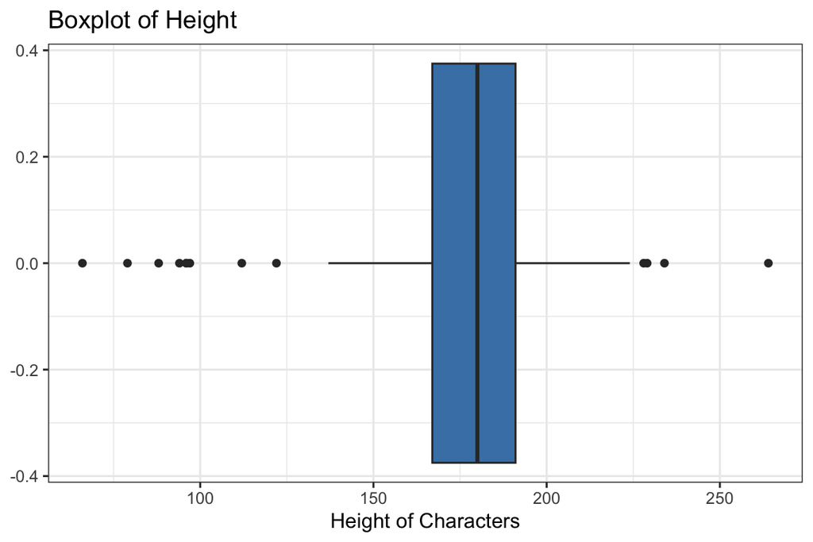

```r
starwars %>%
  drop_na(height) %>%
  ggplot(aes(x = height)) +
  geom_boxplot(fill = "steelblue") +
  theme_bw() +
  labs(title = "Boxplot of Height",
       x = "Height of Characters")
```

### 6.7 Density plots

Density plots show how data is distributed over a contiunous interval

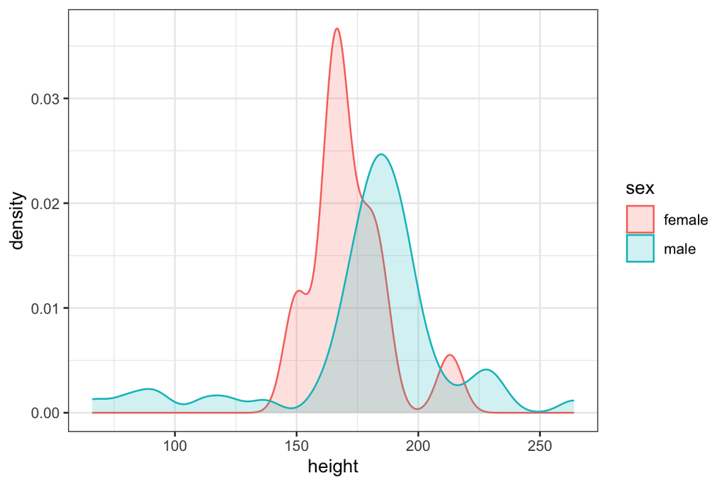

```r
starwars %>%
  drop_na(height) %>%
  filter(sex %in% c("male", "female")) %>%
  ggplot(aes(x = height,
             color = sex,
             fill = sex)) +
  geom_density(alpha = 0.2) + #darkness of fill
  theme_bw()
```

### 6.8 Scatter plots

Scatter plots show the relationship between two variables

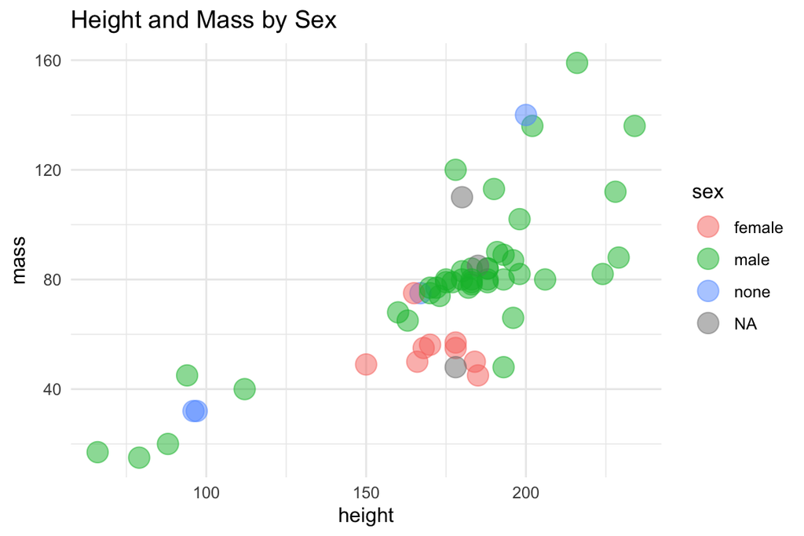

```r
starwars %>%
  filter(mass < 200) %>%
  ggplot(aes(x = height,
             y = mass,
             color = sex)) +
  geom_point(size = 5, alpha = 0.5) +
  theme_minimal() +
  labs(title = "Height and Mass by Sex")
```

### 6.9 Smoothed model

Smoothed model graphs elimate noise from scatter plots

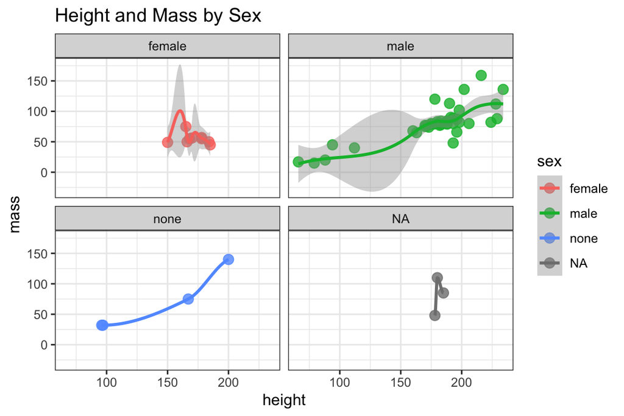

```r
starwars %>%
  filter(mass < 200) %>%
  ggplot(aes(x = height, y = mass, color = sex)) +
  geom_point(size = 3, alpha = 0.8) +
  geom_smooth()+ #draw a smooth linear model over points, 95% standard error
  facet_wrap(~sex)+ #look at data in different boxes based on sex
  theme_bw() +
  labs(title = "Height and Mass by Sex")
```

## 7. Analyze

##### The following are examples of code used to run hypothsis tests

### 7.1 T-test

T-tests are used for comparing means of 2 groups

This code is running a test to determine if there is a difference in mean life expectancy between Africa and Europe:

```r
gapminder %>%
  filter(continent %in% c("Africa", "Europe")) %>%
  t.test(lifeExp ~ continent, data = ., # the data = . tells pipe operator to put data here
         altrnative = "two.sided", # these are default so technically don't need to be included
         paired = FALSE)
```

```
##
##  Welch Two Sample t-test
##
## data:  lifeExp by continent
## t = -49.551, df = 981.2, p-value < 2.2e-16
## alternative hypothesis: true difference in means between group Africa and group Europe is not equal to 0
## 95 percent confidence interval:
##  -23.95076 -22.12595
## sample estimates:
## mean in group Africa mean in group Europe
##             48.86533             71.90369
```

### 7.2 ANOVA

AVONAs are used for comparing means of 3+ groups

This code now compares 3 continents:

```r
gapminder %>%
  filter(year == 2007) %>%
  filter(continent %in% c("Americas", "Europe", "Asia")) %>%
  aov(lifeExp ~ continent, data = .) %>% #aov = anova test
  summary()
```

```
##             Df Sum Sq Mean Sq F value   Pr(>F)
## continent    2  755.6   377.8   11.63 3.42e-05 ***
## Residuals   85 2760.3    32.5
## ---
## Signif. codes:  0 '***' 0.001 '**' 0.01 '*' 0.05 '.' 0.1 ' ' 1
```

The results from this test show a significnat difference. However, if we want a p value for each pairing we need to run this code

```r
gapminder %>%
  filter(year == 2007) %>%
  filter(continent %in% c("Americas", "Europe", "Asia")) %>%
  aov(lifeExp ~ continent, data = .) %>% #aov = anova test
  TukeyHSD()  #lets us look at p-vlaue for each pairing
```

```
##   Tukey multiple comparisons of means
##     95% family-wise confidence level
##
## Fit: aov(formula = lifeExp ~ continent, data = .)
##
## $continent
##                      diff        lwr        upr     p adj
## Asia-Americas   -2.879635 -6.4839802  0.7247099 0.1432634
## Europe-Americas  4.040480  0.3592746  7.7216854 0.0279460
## Europe-Asia      6.920115  3.4909215 10.3493088 0.0000189
```

### 7.3 Chi Squared goodness of fit test

This test is used to comparing categorical data

This code is running a test to determine if there an equal proportion of flowers of each size

```r
flowers %>%
  select(size) %>%
  table() %>%
  chisq.test()
```

```
##
##  Chi-squared test for given probabilities
##
## data:  .
## X-squared = 28.44, df = 2, p-value = 6.673e-07
```

The P-value = 6.673e-07 => this means we reject null, there is a significant difference

### 7.4 Chi Squared test of independence

This test is asking the question, are size and species independent

```r
flowers %>%  # includes size and species data
  table() %>%
  chisq.test()
```

```
##
##  Pearson's Chi-squared test
##
## data:  .
## X-squared = 111.63, df = 4, p-value < 2.2e-16
```

The P-value < 2.2e-16 => this means we reject null, significant, categories are linked

### 7.5 Linear model

This test is looking at the relationship bwtween stopping distance and speed of car

```r
cars %>%
  lm(dist ~ speed, data = .) %>% #dependent as function of indepedent variable
  summary()
```

```
##
## Call:
## lm(formula = dist ~ speed, data = .)
##
## Residuals:
##     Min      1Q  Median      3Q     Max
## -29.069  -9.525  -2.272   9.215  43.201
##
## Coefficients:
##             Estimate Std. Error t value Pr(>|t|)
## (Intercept) -17.5791     6.7584  -2.601   0.0123 *
## speed         3.9324     0.4155   9.464 1.49e-12 ***
## ---
## Signif. codes:  0 '***' 0.001 '**' 0.01 '*' 0.05 '.' 0.1 ' ' 1
##
## Residual standard error: 15.38 on 48 degrees of freedom
## Multiple R-squared:  0.6511, Adjusted R-squared:  0.6438
## F-statistic: 89.57 on 1 and 48 DF,  p-value: 1.49e-12
```

The variables to pay attention to are: Y-intercept, Slope, p value, R2